# 15.1 Computing on the Language

R is an extremely dynamic language. One of the neat features of R is that you can manipulate objects that evaluate to some value just as you would any other object.

There are objects of type `language` that can be manipulated to compute on the language itself. This allows, among other things:

- to examine R objects and take appropriate actions based on the type, class, etc., i.e. *compute on the language*
- to construct code at run time
- to evaluate code in non-standard ways

Changing the normal R evaluation semantics to achieve an effect is called *Non-Standard Evaluation* or *NSE*. Tidyverse uses a lot of NSE to reduce typing in interactive sessions. However, that comes at a cost: Packages that use `tidyverse` functions, for example, have to account for loss of referential transparency. What does that mean?

Consider this simple example.

```r
df <- tibble(x = 1:3, y = 3:1)
filter(df, x == 1)
```

```
## # A tibble: 1 x 2
##       x     y
##   <int> <int>
## 1     1     3
```

is not equivalent to:

```r
my_var <- x
```

```
## Error in eval(expr, envir, enclos): object 'x' not found
```

```r
filter(df,  my_var == 1)
```

```
## Error: object 'my_var' not found
```

or even

```r
my_var <- "x"
filter(df,  my_var == 1)
```

```
## # A tibble: 0 x 2
## # … with 2 variables: x <int>, y <int>
```

So if you use `tidyverse` in your packages, there may be cases where you have to understand NSE. So we dig a bit deeper into R’s evaluation mechanism.

# 15.1.1. Expressions

An expression in R is an object that R can evaluate. That is, it can be sent as input to the R REPL.

The function `quote` returns an expression which can be processed by R.

```r
x <- 20
z <- quote(y <- x * 10)
z
```

```
## y <- x * 10
```

Here `z` is an expression and doesn’t have a numeric value. We will see how we can evaluate such an expression later.

# 15.1.2. Capturing Expressions.

If you call the `plot` function as follows

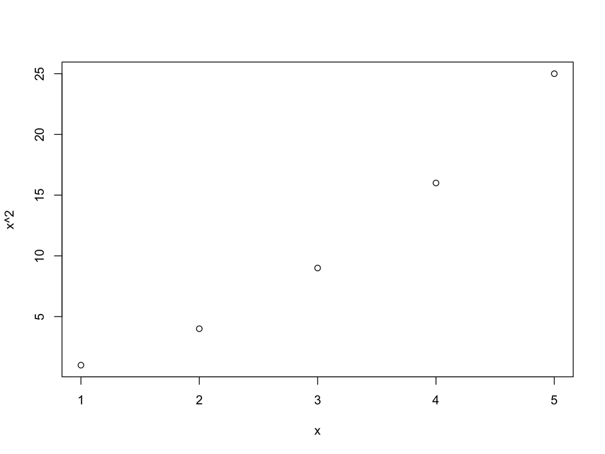

```r
x <- 1:5
plot(x = x, y = x^2)
```

notice how the $y$ axis label is the expression used in your call to `plot`. How did this happen?

Enter `substitute`, which allows you to capture an expression. (We will focus on its use inside a function here and it behaves differently at the command line!)

```r
f <- function(x) {
  substitute(x)
}
f(1:5)
```

```
## 1:5
```

```r
f(a + b + c)
```

```
## a + b + c
```

```r
f(a + b*x + c*x^2)
```

```
## a + b * x + c * x^2
```

Recall that function arguments, which are lazily evaluated, are implemented using *promises*: special objects that capture both the expression and the environment where the expression should be evaluated. They are evaluated exactly once, when the argument value is needed.

`substitute()` uses the promise objects to do its job and captures the unevaluated expression. It is often paired with `deparse` which takes an expression and converts it into a character vector.

```r
g <- function(x) deparse(substitute(x))
g(1:5)
```

```
## [1] "1:5"
```

```r
g(a + b + c)
```

```
## [1] "a + b + c"
```

```r
g(a + b*x + c*x^2)
```

```
## [1] "a + b * x + c * x^2"
```

Note the difference: the results are character vectors!

# 15.1.3. The `quote` function

Let us examine the `quote` function which returns its argument unevaluated.

```r
e1 <- quote(2 + 5)
typeof(e1)
```

```
## [1] "language"
```

```r
class(e1)
```

```
## [1] "call"
```

Sometimes there is a need to evaluate parts of an expression and leave others untouched. Enter: `bquote`.

```r
x <- rnorm(10)
be <- bquote(y <- .(x) * z) # y and z unevaluated, x evaluated
be
```

```
## y <- c(-0.580139005604912, -0.827566401704423, -1.0437661941205,
## 1.86705041295527, 0.118364659410603, 1.70473219251175, 0.453822406410663,
## -1.26288247131583, -1.64121973372632, 1.10340790124194) * z
```

The construct `.()` delineates what is to be evaluated. This means that you can control when certain things get evaluated.

Because of the scoping rules of R, the same expression can return different values depending on when and where it is evaluated, as can be seen below.

```r
({z <- 10; eval(be)})
```

```
##  [1]  -5.801390  -8.275664 -10.437662  18.670504   1.183647  17.047322
##  [7]   4.538224 -12.628825 -16.412197  11.034079
```

```r
({z <- 2; eval(be)})
```

```
##  [1] -1.1602780 -1.6551328 -2.0875324  3.7341008  0.2367293  3.4094644
##  [7]  0.9076448 -2.5257649 -3.2824395  2.2068158
```

(We will talk more about evaluation below, but for now, assume that it takes an expression in the R language, and returns the results of executing that expression as if you typed it at the console.)

# 15.1.4. The `call` object

A `call` object is an unevaluated function call, that is, an unevaluated expression which consists of the named function applied to the given arguments, which could be empty.

Recall our `e1`.

```r
e1
```

```
## 2 + 5
```

One can access elements of the call like your would lists.

```r
e1[[1]]
```

```
## `+`
```

```r
e1[[2]]
```

```
## [1] 2
```

```r
e1[[3]]
```

```
## [1] 5
```

A more complex construct.

```r
e3 <- quote((x + y) * z + w)
e3
```

```
## (x + y) * z + w
```

```r
as.list(e3) ## actual representation
```

```
## [[1]]
## `+`
##
## [[2]]
## (x + y) * z
##
## [[3]]
## w
```

```r
typeof(e3[[1]]) ## symbol
```

```
## [1] "symbol"
```

```r
typeof(e3[[2]]) ## language
```

```
## [1] "language"
```

```r
typeof(e3[[3]]) ## symbol again
```

```
## [1] "symbol"
```

Indexed access, as we know, is also a function call.

```r
qx <- quote(x[5])
qx
```

```
## x[5]
```

```r
length(qx)
```

```
## [1] 3
```

```r
qx[[1]]
```

```
## `[`
```

```r
qx[[2]]
```

```
## x
```

```r
qx[[3]]
```

```
## [1] 5
```

```r
x
```

```
##  [1] -0.5801390 -0.8275664 -1.0437662  1.8670504  0.1183647  1.7047322
##  [7]  0.4538224 -1.2628825 -1.6412197  1.1034079
```

How about keyword access? It is quite similar.

```r
e2 <- quote(plot(x = age, y = weight))
e2[[1]]
```

```
## plot
```

```r
e2[[2]]
```

```
## age
```

```r
e2[[3]]
```

```
## weight
```

```r
e2$x
```

```
## age
```

```r
e2$y
```

```
## weight
```

Since `plot` is the name of a function, let us examine it.

```r
typeof(e2[[1]])
```

```
## [1] "symbol"
```

So it is actually a symbol, i.e. a name of an object. These can be manipulated. For example, below, we change the name and add another argument. (The functions `as.name` and `as.symbol` are synonymous.)

```r
e2[[1]] <- as.symbol("foo")
e2
```

```
## foo(x = age, y = weight)
```

```r
e2$z <- as.name("height")
e2
```

```
## foo(x = age, y = weight, z = height)
```

To see a dynamic application of `call` objects, consider the following example. Suppose you have some data in a vector `x`.

You wish to write a function `apply_f` to let the user provide the name of any R function (as a string) that operates on the vector, execute it and return the results.

So `apply_f(f = "mean", x)` should return `mean(x)` and `apply_f(f = "median", x)` should return `median(x)`, etc.

Let us begin by examining a few examples.

```r
fName <- "mean"
typeof(fName)
```

```
## [1] "character"
```

```r
fCall <- call(fName)
typeof(fCall)
```

```
## [1] "language"
```

```r
class(fCall)
```

```
## [1] "call"
```

So now that `fCall` is actually a call, we can work with it.

```r
fCall[[1]]
```

```
## mean
```

```r
fCall[[2]]
```

```
## Error in fCall[[2]]: subscript out of bounds
```

The second resulted in an error because there were no arguments. Let’s put in an argument, our `x`.

```r
fCall[[2]] <- x
fCall
```

```
## mean(c(-0.580139005604912, -0.827566401704423, -1.0437661941205,
## 1.86705041295527, 0.118364659410603, 1.70473219251175, 0.453822406410663,
## -1.26288247131583, -1.64121973372632, 1.10340790124194))
```

Now, we can actually evaluate this expression.

```r
eval(fCall)
```

```
## [1] -0.01081962
```

Let us now change the `mean` to `median`.

```r
fCall <- call("median")
fCall[[2]] <- x
eval(fCall)
```

```
## [1] -0.2308872
```

# 15.1.5. Evaluation

Evaluation is the opposite of quoting. Each application of `eval` peels off one layer of `quote`.

```r
eval(e1)
```

```
## [1] 7
```

```r
e5 <- quote(quote(2 + 3))
e5A <- eval(e5)
e5A
```

```
## 2 + 3
```

```r
typeof(e5A)
```

```
## [1] "language"
```

```r
e5B <- eval(e5A)
typeof(e5B)
```

```
## [1] "double"
```

```r
e5B
```

```
## [1] 5
```

The function `eval` can also take an environment as a second argument. This specifies the environment in which the evaluation can take place.

*Any arguments needed for evaluating the expression are first sought in that environment.*

For example, consider:

```r
rm(z)
be
```

```
## y <- c(-0.580139005604912, -0.827566401704423, -1.0437661941205,
## 1.86705041295527, 0.118364659410603, 1.70473219251175, 0.453822406410663,
## -1.26288247131583, -1.64121973372632, 1.10340790124194) * z
```

```r
eval(be) # error z is not found
```

```
## Error in eval(be): object 'z' not found
```

However, if we set up `z` appropriately, we should be fine.

```r
e <- new.env()
e$z <- 10
w <- eval(be, e)
w
```

```
##  [1]  -5.801390  -8.275664 -10.437662  18.670504   1.183647  17.047322
##  [7]   4.538224 -12.628825 -16.412197  11.034079
```

Since, environments and lists and data frames all bind names to values in a similar way (`$`, `[[`), the second argument need not be just an environment:

```r
print(eval(be, list(z = 10)))
```

```
##  [1]  -5.801390  -8.275664 -10.437662  18.670504   1.183647  17.047322
##  [7]   4.538224 -12.628825 -16.412197  11.034079
```

```r
print(eval(be, data.frame(z = 10)))
```

```
##  [1]  -5.801390  -8.275664 -10.437662  18.670504   1.183647  17.047322
##  [7]   4.538224 -12.628825 -16.412197  11.034079
```

# 15.1.6. NSE in `subset`

`subset` is an R function that selects variables and rows in a data frame based upon a condition.

```r
d <- data.frame(a = 1:10, b = 6:15, c = 16:25)
subset(d, a < 4)
```

```
##   a b  c
## 1 1 6 16
## 2 2 7 17
## 3 3 8 18
```

You can also select variables.

```r
## select all vars other than b
subset(d, a < 3, select = -b)
```

```
##   a  c
## 1 1 16
## 2 2 17
```

How does it work? Let us start by writing our own subset function called `subset2` using what we have learned so far. For the `eval` part, we will set things up so that the data frame that is passed as the argument is used as the environment where the expression is evaluated.

```r
subset2 <- function(x, condition) {
    condition_call <- substitute(condition)
    r <- eval(condition_call, x)
    x[r, ]
}
subset2(d, a < 4)
```

```
##   a b  c
## 1 1 6 16
## 2 2 7 17
## 3 3 8 18
```

```r
subset2(d, b < 3)
```

```
## [1] a b c
## <0 rows> (or 0-length row.names)
```

So far, so good.

# 15.1.7. Breaking Bad

Let us test how good our `subset2` function is. We set some global variables in our session.

```r
y <- 4
x <- 4
condition <- 4
condition_call <- 4
```

Let us try some things.

```r
subset2(d, a == 4)
```

```
##   a b  c
## 4 4 9 19
```

```r
subset2(d, a == x)
```

```
##     a  b  c
## 1   1  6 16
## 2   2  7 17
## 3   3  8 18
## 4   4  9 19
## 5   5 10 20
## 6   6 11 21
## 7   7 12 22
## 8   8 13 23
## 9   9 14 24
## 10 10 15 25
```

Hmmm..

```r
subset2(d, a == condition)
```

```
## Error in eval(condition_call, x): object 'a' not found
```

```r
subset2(d, a == condition_call)
```

```
## [1] a b c
## <0 rows> (or 0-length row.names)
```

Many wrong/wierd answers. Why?

```r
subset2(d, a == x)
```

```
##     a  b  c
## 1   1  6 16
## 2   2  7 17
## 3   3  8 18
## 4   4  9 19
## 5   5 10 20
## 6   6 11 21
## 7   7 12 22
## 8   8 13 23
## 9   9 14 24
## 10 10 15 25
```

Let us focus on the call `subset2(d, a == x)`.

When `subset2` evaluates the `condition_call`, the following happens:

- `x` is bound to a promise that evaluates to `d` the data frame passed as the argument
- The value of `condition_call` is the *expression* `a == x`,
- The value of `a` is found in the the data frame `x`, which is `d`
- The value for `x` is looked for in the data frame, and it is not found.
- So R looks to the enclosing environment, which is the environment inside the function `subset2`. In that environment, `x` is found and it is `d`
- So the expression `a == x` becomes, in effect, `d$a == d`
- Since `d` is a data frame, R’s coercion will actually create a data frame of three colummns of `d$a` and return a matrix of `TRUE` or `FALSE`.

```r
d$a == d
```

```
##          a     b     c
##  [1,] TRUE FALSE FALSE
##  [2,] TRUE FALSE FALSE
##  [3,] TRUE FALSE FALSE
##  [4,] TRUE FALSE FALSE
##  [5,] TRUE FALSE FALSE
##  [6,] TRUE FALSE FALSE
##  [7,] TRUE FALSE FALSE
##  [8,] TRUE FALSE FALSE
##  [9,] TRUE FALSE FALSE
## [10,] TRUE FALSE FALSE
```

- finally the expression `x[r, ]` will turn that matrix of `TRUE/FALSE` into one long vector and return matching rows of `d`. Rules of logical indexing will apply to turn up `NA` values.

The *root cause* of the problem is that R found `x` in the wrong place. We need to control this and tell R where to look for variables like `x` are not directly in the data frame.

# 15.1.8. The Fix

```r
subset3 <- function(x, condition) {
  condition_call <- substitute(condition)
  r <- eval(condition_call, x, parent.frame())
  x[r, ]
}
subset3(d, a == 4)
```

```
##   a b  c
## 4 4 9 19
```

```r
subset3(d, a == x)
```

```
##   a b  c
## 4 4 9 19
```

```r
subset3(d, a == condition)
```

```
##   a b  c
## 4 4 9 19
```

```r
subset3(d, a == condition_call)
```

```
##   a b  c
## 4 4 9 19
```

There are other nuances that we will not get into. For further detail, refer to Chapter 20 of of [Advanced R](https://adv-r.hadley.nz) by Hadley Wickham.

# 15.1.9. Example: `dplyr` programming

Since `dplyr` uses NSE a lot, there are several functions provided to aid in programming. In particular, `dplyr` relies on the `rlang` package that provides functions for capturing expressions, along with the environments.

In situations such as the following

```r
my_select <- function(df, var) {
    dplyr::select(df,  var)
}
```

where we want to select a variable, say, the function `rlang::enquo` and the unquote operator `!!` are provided.

```r
my_select <- function(df, var) {
    my_var <- rlang::enquo(var)
    dplyr::select(df,  !! my_var)
}
```

so that

```r
my_select(d, a)
```

```
##     a
## 1   1
## 2   2
## 3   3
## 4   4
## 5   5
## 6   6
## 7   7
## 8   8
## 9   9
## 10 10
```

will work as expected. Also `rlang::sym` is provided to convert a string into a symbol for use if the argument `var` is a string.

# 15.1.10. `parse()`

`parse()` is the opposite of `deparse()`. Recall that `deparse()` turns expressions into strings; `parse` does the opposite: it turns strings into expressions.

This means that code can be dynamically generated as a string.

```r
x <- "print('I am a string')"
parse(text = x)
```

```
## expression(print('I am a string'))
```

Now this can be evaluated.

```r
eval(parse(text = x))
```

```
## [1] "I am a string"
```

It is as if the command `print('I am a string')` was typed into an R prompt!

The `tidyverse` package has `rlang::parse_expr` function which will parse work well within the tidyverse ecosystem.